# PS3192: Introduction to R Worksheet

Matteo Lisi

24 january 2025

# 1 The R prompt

The R command prompt looks like `>` (see picture below). You can type in commands and they will run once you hit `Enter`.

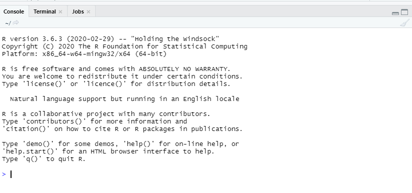

At its simplest, you can think of this as a fancy calculator. For instance, you can use operators like `+`, `-`, `*` (for multiplication), `/`, etc. to do calculations:

```r
2+2
```

```
## [1] 4
```

```r
3*2
```

```
## [1] 6
```

R has also many additional *functions* that are used for a variety of purposes. For example if you type `citation()` and press enter, R will give you some information about how you can cite R in a report or your dissertation:

```r
citation()
```

```
##
##   R Core Team (2024). _R: A Language and Environment for Statistical
##   Computing_. R Foundation for Statistical Computing, Vienna, Austria.
##   <https://www.R-project.org/>.
##
## A BibTeX entry for LaTeX users is
##
##   @Manual{,
##     title = {R: A Language and Environment for Statistical Computing},
##     author = {{R Core Team}},
##     organization = {R Foundation for Statistical Computing},
##     address = {Vienna, Austria},
##     year = {2024},
##     url = {https://www.R-project.org/},
##   }
##
## We have invested a lot of time and effort in creating R, please cite it
## when using it for data analysis. See also 'citation("pkgname")' for
## citing R packages.
```

Note that R is case-sensitive (it consider uppercase and lower case letters as different symbols altogether). Hence if you type the same command but with an uppercase C for example, you will get an error:

```r
Citation()
```

```
## Error in Citation(): could not find function "Citation"
```

You can get help on any function by typing `?` before it. For example:

```r
?citation
?sum
?mean
```

The help isn’t always as helpful as you might wish (can appear a bit cryptic when you are just starting), but it’s a good first place to look for help. Internet search engines are also your friend!

## 1.1 Simple Arithmetic

Answer the following calculations using the R prompt:
$$4829 + 5029 =$$
$$28 \times 82 =$$
$$5/3 =$$
$$7^5 =$$
$$\sqrt{20} =$$
(hint: use the `sqrt()` function)

## 1.2 Using functions

You have seen that there is quite a lot of calculations that we can do using simple operations such as `+` or `*`, but for more advanced calculations we need to use **functions**. Above we have seen an example of a function that use a single argument to compute the square root of a number. Most functions in R however tend to allow more than one argument, several of which tend to have “default” values.

An example is the `round()` function, which can be used to round a number to the nearest whole number, for example

```r
round(3.141593)
```

```
## [1] 3
```

Suppose however I want to round to two decimal places — that is I should get `3.14`. The function `round()` support a second argument that specify the number of digits (you can see this in the help of the function — type `?round` in your command prompt to see this).

Another useful function that requires multiple arguments is `seq()`. Try to have a look at the help of the function typing `?seq` in the command prompt, then use the function to answer the following:

- Create a sequence of increasing values from 0 to 100 in steps of 5.
- Create a sequence of *decreasing* values from 1 to 0 in steps of -0.05

## 1.3 Logical Operators

- `>` means *greater than*, while < means *less than*:

```r
7 > 3

2*5 < 8
```

- `==` means *is equal to*:

```r
6/2 == 3
```

- `&` means *and*

```r
(3 == 4-1) & (9 > 4)
(8 < 18) & (-1 > 1)
```

- `|` means *or*

```r
(3 == 4-1) | (9 > 4)
(8 < 18) | (-1 > 1)
```

- `!=` means *not equal*

```r
10 != 5+6
```

## 1.4 Assignment

We can assign a variable using `<-` or `=`. Think of this as storing a number (or a string) for future use.

```r
my_number <- 6
print(my_number)
my_number + 3
my_number > 2
```

There are some differences between `<-` and `=` but these are outside the scope of module. Ask about them later in the module if you would like to know more! In the meantime, do your best to use the same symbols that we use.

# 2 Working with scripts

A big advantage of `R` is that it makes it very easy to work with scripts. A script is simply a collection of commands (like the above) that we can save in a file and then run at a later date. This is very useful if we need to rerun the same set of commands again an again (time-saving!) or if we want to have a perfect record of how we processed our data (reproducible research)!

Make a new script using File > New File > R Script, or using the bottom on the top-left corner of the menu. Or for extra style points, you can use the `Ctrl+Shift+N` shortcut.

Try typing out a few of commands.

## 2.1 The workspace

The workspace is your current R working environment and includes any user-defined objects (vectors, matrices, data frames, lists, functions).

It is good practice to add a command to **clear** the workspace, that is delete all variables in memory, at the top of a script, so that we are sure to start with a ‘clean slate’ and ensure that no leftover variables from previous sessions interfere with your current work.

You can clear the workspace with the following command:

```r
rm(list=ls())
```

This is a composite command, so let’s unpack a bit:

- `ls()` lists all objects (variables, functions, datasets, etc.) currently stored in the workspace.
- `list=ls()` tells `rm()` that its argument are all objects returned by `ls()` (joined together as a “list” — more on this below), effectively clearing the workspace.
- `rm()` is the function that removes specified objects from memory.

Running `rm(list=ls())` at the beginning of a script thus remove all variables currently in the workspace. Note that `rm` command permanently deletes objects in the workspace (there is no ‘undo’ button), so be careful when using it in an interactive sessions.

(If you only want to remove specific variables, you can list them explicitly, e.g., `rm(x, y, z)`.)

## 2.2 Running code in a script

If you want to run the line that your cursor is currently on, press `Ctrl+Enter`.

You can also mouse-drag to select one or more lines, and then again press `Ctrl+Enter`.

To run the whole script, press `Ctrl+Shift+Enter`.

You can also find these options by clicking on the Run icon in the menu bar.

## 2.3 Commenting Code

It is very important to comment your code. This may sometimes feel like a waste of time, but it is a really good habit to get into. Comments start with a `#` symbol and they allow you to leave notes about what a line of code does. This will help others understand what you’ve done and why. It will also help future-you remember what past-you was thinking!

```r
# This is a comment
print('This is not a comment')
```

```
## [1] "This is not a comment"
```

```r
print('Neither is this.') # we can also put comments at the end of a line.
```

```
## [1] "Neither is this."
```

## 2.4 Debugging

Having bugs — that is errors or unexpected or unexpected behavior in your code that prevents it from running correctly — is common, especially while learning. When there is a bug in your code, don’t panic. This is perfectly normal.

- First try and work out which line of code is causing the problems.
- Check for simple syntax problems (such as missing commas, the wrong number of type of brackets, etc).
- Check that your variables have sensible values (perhaps your code is expecting `x` to be a number but you’ve set it to a factor?)
- Restart your R session if needed — sometimes, clearing the workspace (`rm(list=ls())`) and re-running the script from the beginning can help.

# 3 Vectors, Lists and Dataframes

## 3.1 Concatenation and indexing

When we are analysing data, we are often working with vectors and lists of numbers (for example, the height of everybody in this room). We can *concatenate* several numbers togethers:

```r
many_numbers <- c(3, 1, 4, 6)
print(many_numbers)
2 * many_numbers
```

We can index each entry on it’s own using square brackets: `[` and `]`. For example:

```r
many_numbers <- c(3, 1, 4, 6)
many_numbers[3]
```

```
## [1] 4
```

Vectors are good if we want to store the the same type of information in each position. If we try to store different types of information, we will either get an error, or R will automatically apply a transform, which may cause difficult to find bugs later on. For example, what is going on with the the code below:

```r
x <- c("adfc", 6.5)
x[2] + 1
```

## 3.2 Lists

We can store different types of information in a list. Lists are very powerful, but the syntax can get a little ugly, as we need to use double brackets to index positions.

```r
x <- list("adfc", 6.5)
x[[2]] + 1
```

We can name entries in a list. This can make it easier to index information using the `$` symbol:

```r
my_list <- list(a_character = "5", a_number = 6)
my_list$a_number
```

```
## [1] 6
```

We can have lists of lists too:

```r
pets <- list(
  names = c("leo", "sally", "daisy", "mungo"),
  creature = c("cat", "dog", "dog", "cat"),
  still_alive = c(FALSE, FALSE, FALSE, TRUE))
```

Can you make a list summarising the different modules that you are taking this year?

## 3.3 `For` and `if` statements

For ‘loops’ and if statements are some of the basic building blocks of computer languages. They allow us to repeat the same operations over different values, or ask a question about some variables and run code only *if* certain conditions are met.

An example of `for` loop — run it in your command prompt.

```r
for (x in 1:10) {
    print(x^2)
}
```

And an example of an `if` statement

```r
module = "PS3192"

if(module == "PS3192") {
    print("this is my favourite course")
} else {
    print("this course is quite good")
}
```

As an exercise, write a script that combines a `for` loop and an `if` statement to process numbers from **1 to 100**:

1. Use a `for` loop to iterate over numbers from **1 to 100**.
2. Inside the loop, check whether each number is **divisible by 2**.
   - *Hint:* Use the **modulo operator** `%%`, which returns the remainder of a division.
   - Example:
     - `4 %% 2` returns `0` (divisible by 2)
     - `5 %% 2` returns `1` (not divisible by 2)
   - A number is divisible by 2 if the remainder is `0`, i.e., `number %% 2 == 0`.
3. If a number is **divisible by 2**, print it to the console. Otherwise, move to the next number.

## 3.4 Dataframes

We will be using dataframes a lot in this module: they are essentially a list-of-lists. You can think of them as all the information you might have in a table or spreadsheet.

```r
pets <- data.frame(
  n = 1:4,
  names = c("leo", "sally", "daisy", "mungo"),
  creature = c("cat", "dog", "dog", "cat"),
  still_alive = c(FALSE, FALSE, FALSE, TRUE))
```

We can use the `$` operator to reference a column in the dataframe.

```r
pets$names
```

```
## [1] "leo"   "sally" "daisy" "mungo"
```

```r
pets$still_alive == TRUE
```

```
## [1] FALSE FALSE FALSE  TRUE
```

```r
pets[pets$still_alive == TRUE,]
```

```
##   n names creature still_alive
## 4 4 mungo      cat        TRUE
```

We can get an idea of the variables in a dataset by using the functions `str()` or `summary()`. Run and examine the output of the following code:

```r
str(pets)
```

```
## 'data.frame':    4 obs. of  4 variables:
##  $ n          : int  1 2 3 4
##  $ names      : chr  "leo" "sally" "daisy" "mungo"
##  $ creature   : chr  "cat" "dog" "dog" "cat"
##  $ still_alive: logi  FALSE FALSE FALSE TRUE
```

```r
summary(pets)
```

```
##        n           names             creature         still_alive
##  Min.   :1.00   Length:4           Length:4           Mode :logical
##  1st Qu.:1.75   Class :character   Class :character   FALSE:3
##  Median :2.50   Mode  :character   Mode  :character   TRUE :1
##  Mean   :2.50
##  3rd Qu.:3.25
##  Max.   :4.00
```

# 4 Probability Distributions

We will be working with some *probability distributions* in this course. You should have encountered these before

## 4.1 The Normal (Gaussian) Distribution

The normal distribution is very common. It has two parameters, the mean ($\mu$) and the standard deviation ($\sigma$).

```r
# rnorm generates random numbers from a normal distribution
my_random_numbers <- rnorm(n = 100, mean =20, sd = 5)

# we can look at the mean and sd of our sample
mean(my_random_numbers)
```

```
## [1] 19.66533
```

```r
sd(my_random_numbers)
```

```
## [1] 5.179215
```

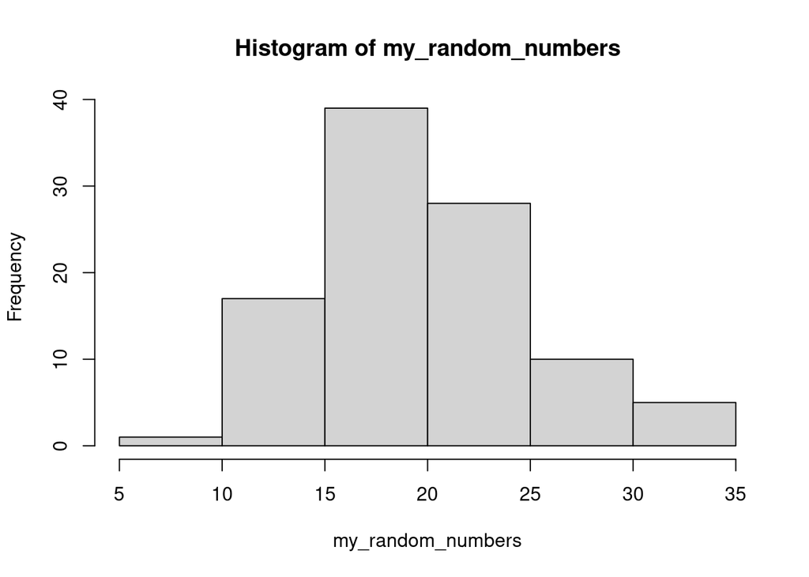

```r
# plot a histogram
hist(my_random_numbers)
```

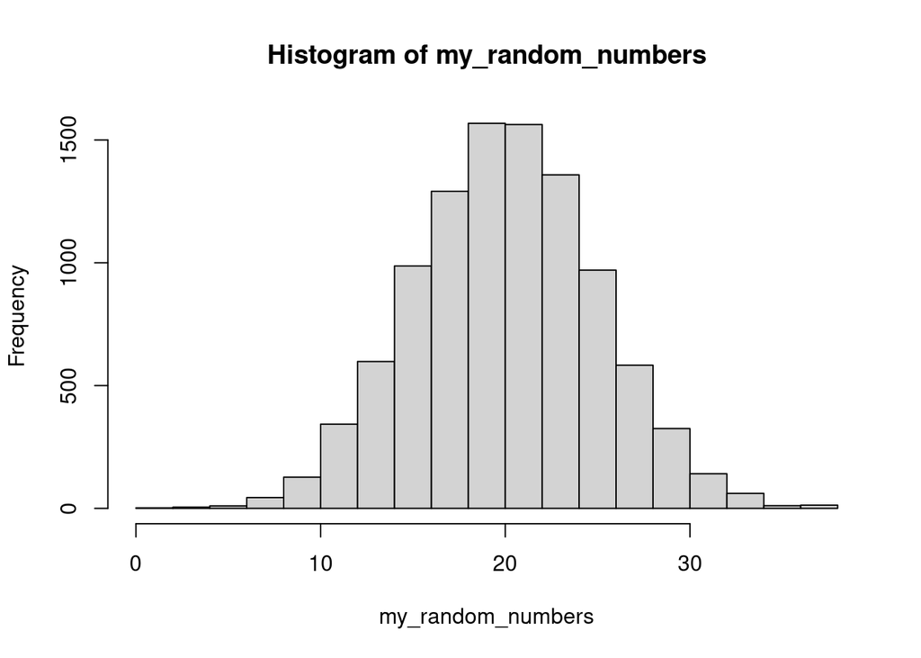

```r
# repeat, but with a larger n!
my_random_numbers <- rnorm(n = 10000, mean =20, sd = 5)

# plot a histogram
hist(my_random_numbers)
```

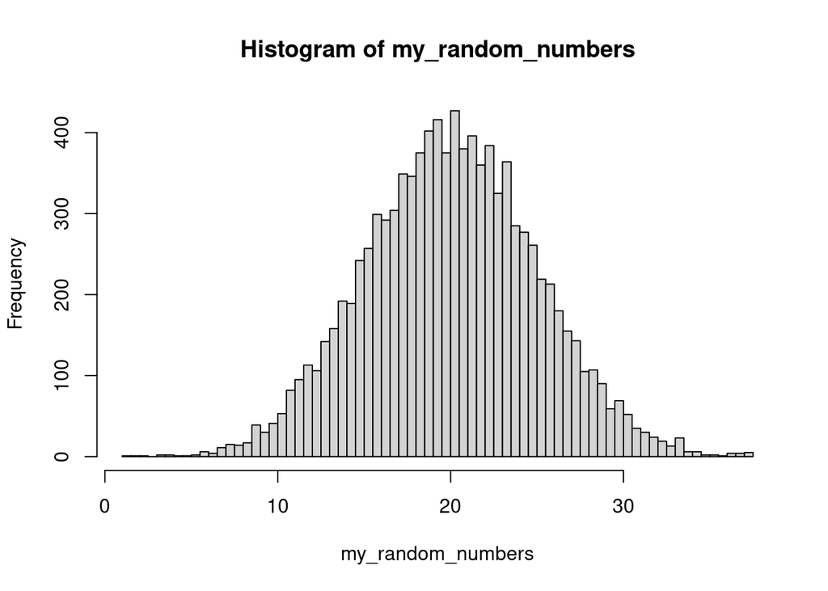

```r
# we can change the number of bins!
hist(my_random_numbers, breaks = 100)
```

Hopefully this bell-shaped curve is familiar to you?

## 4.2 Plotting

In the previous section you have create a histogram, which is a type of plot used to display how a single variable is distributed. Another very common type of plot is the ‘scatterplot’, which is used to show the relationship between two variables. In R we can create this with the `plot()` function.

For example:

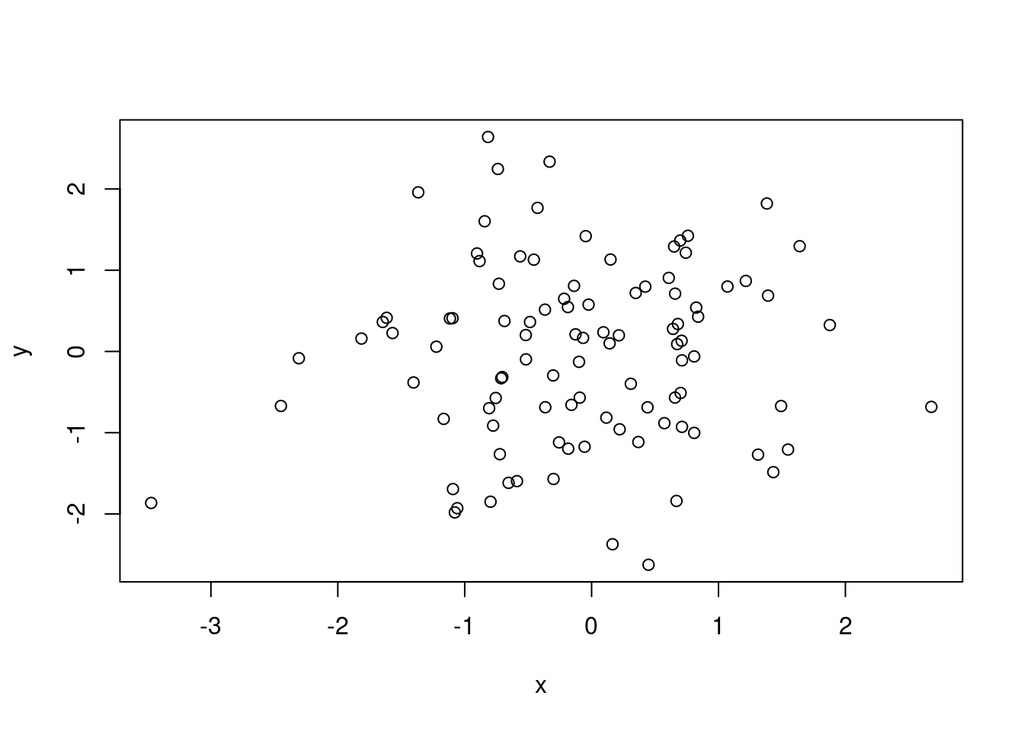

```r
# create some random, normally distributed variables (100 values)
x <- rnorm(100)
y <- rnorm(100)

# plot them
plot(x,y)
```

To get some practice with plotting, try creating the following plots:

- Use the `seq()` function to generate a sequence of values from **-10 to 10**. Store these values in a variable, and use them to plot the function:
  $$y =
  -x^2$$
- Modify the appearance of the plot:
  - Set `type = "l"` to draw a continuous line instead of points.
  - Use the arguments `col` and `lwd` to change the line color and width, respectively.
- Add another curve to the same plot using the `lines()` function. For this new line, replace $x$ with $x + 5$, so that you are plotting:
  $$y =
  -(x+5)^2$$
  - What do you notice about the position of this new curve compared to the original one?

# 5 Custom functions

It is often useful to expand R capabilities by writing your own function (especially when you need to repeat operations many times). For example, in this way we can add a function that compute the values of $Y$ in the mathematical function we have plotted in the previous section:

```r
quadratic_function <- function(x, a=0){
  y <- -(x-a)^2
  return(y)
}
```

## 5.1 Exercises

1. Write an R script to plot a straight line using the equation $y = mx + c$ where the slope $m = 2$ and the intercept $c = 1$. Define $x$ as a sequence of numbers from -5 to 5, and then plot the resulting $y$ values.
2. Create a function in R to compute the distance traveled by an object moving with a constant speed of 5 meters per second. Use the formula $d = 5t$, where $d$ is the distance and $t$ is the time. Plot a graph of distance as a function of time for t values ranging from 0 to 10 seconds.
3. Write an R script that generates two lines with random slopes and intercepts using the command `rnorm(1)` (e.g., `a <- rnorm(1)` to assign a random value to `a`). Next, calculate which line has the steeper slope. Plot both lines on the same graph and use visual cues (such as line thickness or color) to highlight the steeper line. The script should function each time it is executed (sourced), meaning that new lines with random slopes and intercepts are generated every time the script runs. (Hint: Use an `if` statement to check which line has the steeper slope and ensure that the line with the higher slope is always drawn thicker or in a more salient color each time the script runs).

## 5.2 Linear regression

If you have completed all the worksheet, you are ready to dive into some real data.

Two datasets are available on Moodle for you to load into R and explore:

### 5.2.1 `earnings` dataset

This dataset contains the annual earnings (in $), the heights (in inches) and the sex (male/female) of a random sample (N=1192) of adult Americans, surveyed in the 1990.

Download the file `earnings.csv` from the Moodle page, copy it in your working directory, and run the following code:

```r
earnings <- read.csv("earnings.csv")
str(earnings)
```

```
## 'data.frame':    1192 obs. of  3 variables:
##  $ female: int  0 1 1 1 1 1 1 0 0 0 ...
##  $ earn  : num  50000 60000 30000 50000 51000 9000 29000 32000 2000 27000 ...
##  $ height: int  74 66 64 63 63 64 62 73 72 72 ...
```

Use this to answer the question: *do taller people have higher earnings?*

*Hint:* you can use the `lm()` function to for a linear regression model. For example, the following code would estimate a regression of income on height

```r
model <- lm(earn ~ height, data=earnings)
```

You can print a summary of the results by applying the `summary` function to the fitted model object, that is by running:

```r
sumary(model)
```

### 5.2.2 `bechdel` dataset

The Bechdel test is a tool to measure, at least approximately, gender bias in the movie business. It was originally formulated by cartoonist Alison Bechdel in a 1985 strip from her “Dykes To Watch Out For” series, reproduced below:

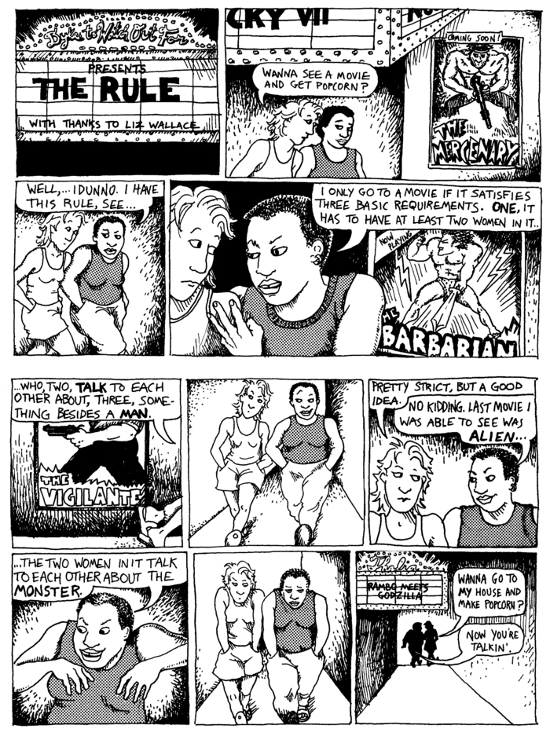

The dataset (put together by [fivethirtyeight](https://projects.fivethirtyeight.com/polls/) contains information about 1776 movies from 1990 to 2013, including whether they passed the test or not. Load the dataset in R as follow:

```r
bechdel <- read.csv("bechdel.csv")
str(bechdel)
```

```
## 'data.frame':    1776 obs. of  7 variables:
##  $ title         : chr  "21 & Over" "Dredd 3D" "12 Years a Slave" "2 Guns" ...
##  $ year          : int  2013 2012 2013 2013 2013 2013 2013 2013 2013 2013 ...
##  $ binary        : chr  "FAIL" "PASS" "FAIL" "FAIL" ...
##  $ budget_2013   : int  13000000 45658735 20000000 61000000 40000000 225000000 92000000 12000000 13000000 130000000 ...
##  $ domgross_2013 : int  25682380 13611086 53107035 75612460 95020213 38362475 67349198 15323921 18007317 60522097 ...
##  $ gross_millions: num  25.7 13.6 53.1 75.6 95 ...
##  $ log_gross     : num  3.25 2.61 3.97 4.33 4.55 ...
```

It includes the following variables:

- `title`: Movie title.
- `year`: Release year.
- `binary`: Whether the movie passes the Bechdel test (`PASS` or `FAIL`).
- `budget_2013`: Production budget (adjusted to 2013 dollars).
- `domgross_2013`: Domestic box office revenue (2013 dollars).
- `gross_millions`: Total box office revenue in millions.
- `log_gross`: Log-transformed total revenue.

You can use this dataset to explore questions such as:

- what proportion of movies fails to pass the test
- do movies that fails to pass the test have larger budget? do they make more or less revenue?